# cnmf_programs_in_ACC

## KRT14

`geom_smooth()` using formula ‘y ~ x’

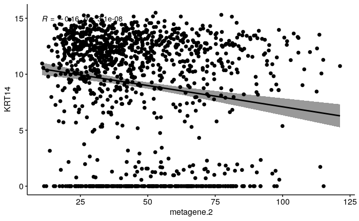

## ACTA2

`geom_smooth()` using formula ‘y ~ x’

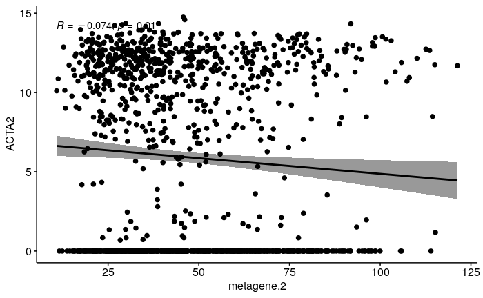

## TAGLN

`geom_smooth()` using formula ‘y ~ x’

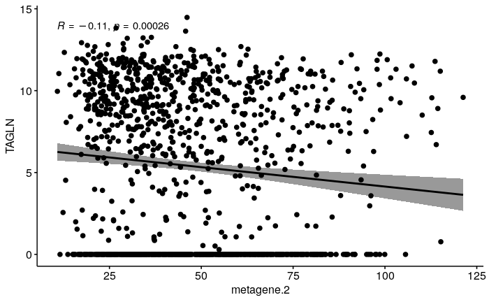

## MYLK

`geom_smooth()` using formula ‘y ~ x’

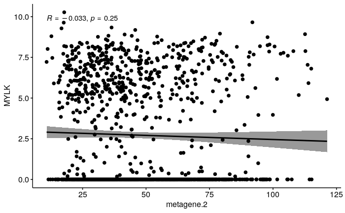

## DKK3

`geom_smooth()` using formula ‘y ~ x’

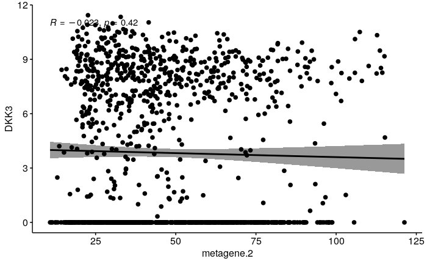

NA

# metagene 2 with acc genes

```r
notch_genes = c("JAG1","JAG2","NOTCH3","NOTCH2","NOTCH1","DLL1","MYB","HES4","HEY1","HEY2","NRARP")

acc_cancerCells_noACC1 = subset(all_acc_cancer_cells,subset = patient.ident!= "ACC1")
for (gene in notch_genes) {

  lum_score_vs_programScore = FetchData(object = acc_cancerCells_noACC1,vars = c("metagene.2",gene))
p = ggscatter(lum_score_vs_programScore, x = "metagene.2", y = gene,
          add = "reg.line", conf.int = TRUE,
          cor.coef = TRUE, cor.method = "pearson")
print_tab(plt = p,title = gene)
}
```

## JAG1

`geom_smooth()` using formula ‘y ~ x’

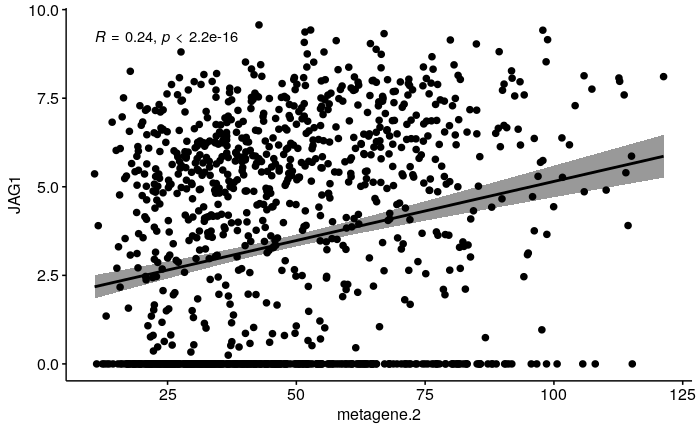

## JAG2

`geom_smooth()` using formula ‘y ~ x’

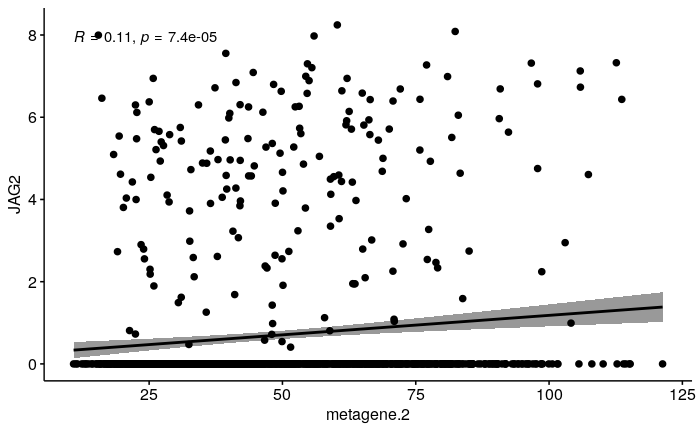

## NOTCH3

`geom_smooth()` using formula ‘y ~ x’

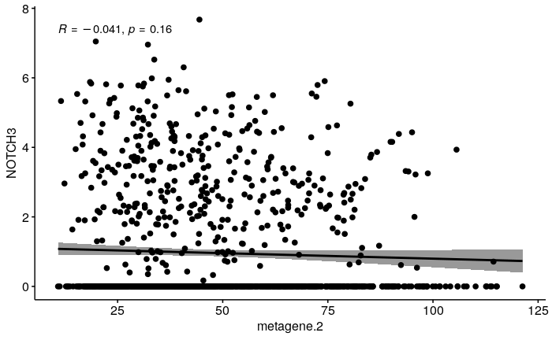

## NOTCH2

`geom_smooth()` using formula ‘y ~ x’

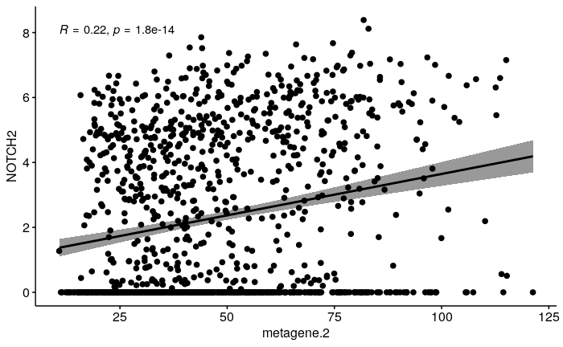

## NOTCH1

`geom_smooth()` using formula ‘y ~ x’

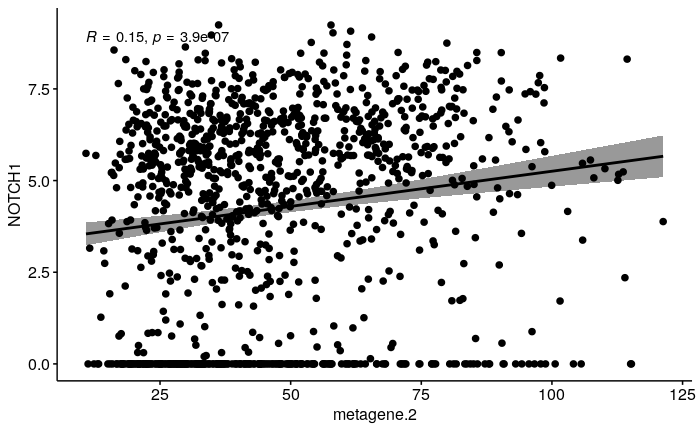

## DLL1

`geom_smooth()` using formula ‘y ~ x’

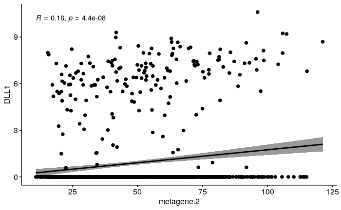

## MYB

`geom_smooth()` using formula ‘y ~ x’

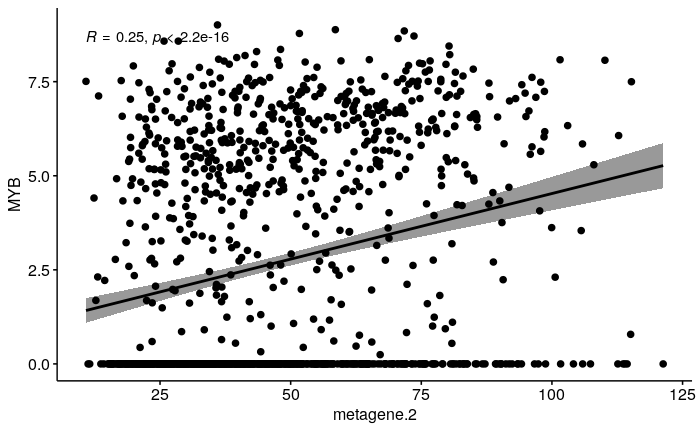

## HES4

`geom_smooth()` using formula ‘y ~ x’

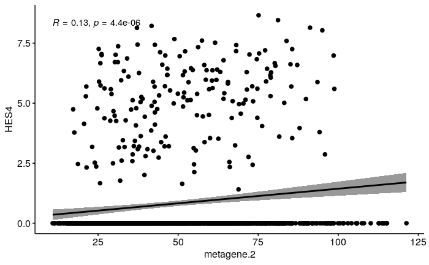

## HEY1

`geom_smooth()` using formula ‘y ~ x’

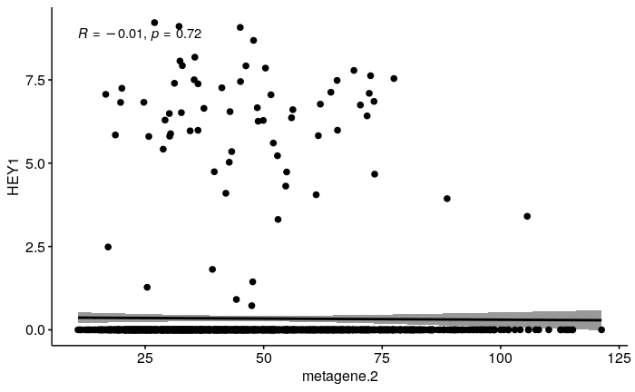

## HEY2

`geom_smooth()` using formula ‘y ~ x’

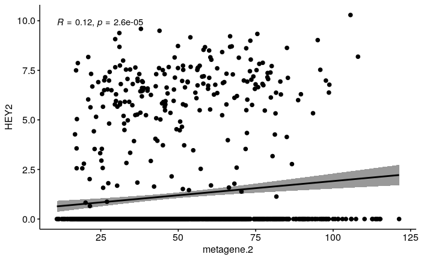

## NRARP

`geom_smooth()` using formula ‘y ~ x’

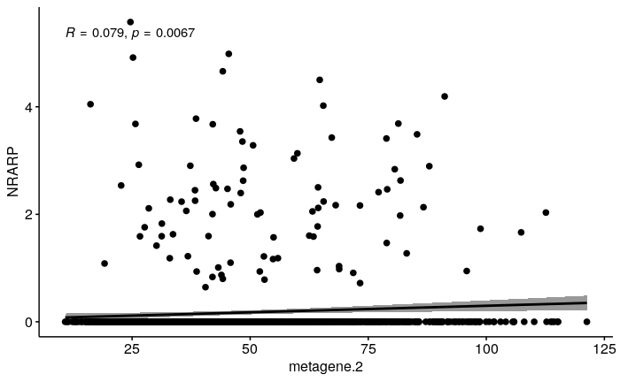

NA